# RSV (AREXVY) - Atrial fibrillation

OpenSourcePV

Data Lock Point: 2024_01_26

# 1 Quantitative Signal status

## 1.1 Disproportionality

The vaccine-event combination “RSV (AREXVY) - Atrial fibrillation” was **a signal of disproportionate reporting** with an EB05 value of 2.84.

The threshold for being flagged as a signal of disproportionate reporting is an EB05>=2 meaning that there there is a 95% probability that the reporting of Atrial fibrillation was at least twice post exposure to RSV (AREXVY) than post all vaccines [1]. Under the assumption of no causality between RSV (AREXVY) and Atrial fibrillation and no bias it would have been expected to observe an EBGM of 1.

It means that the quantified causality criterion of strength of association is **met**.

*It is to be noted that the nature of the spontaneous report does not provide reliable estimates of the strength of association (whatever the choice of the disproportionality method) and that some reporting bias or difference in demographic characteristics might explain the (un)observed disproportion*.

## 1.2 Time-to-onset

The vaccine-event combination “RSV (AREXVY) - Atrial fibrillation” was **not a signal of unexpected time-to-onset distribution** with a p-value of the two-sample Kolmogorov-Smirnov test being 0.0327303 and distance between the two empirical cumulative distributions being of 30.6682207%.

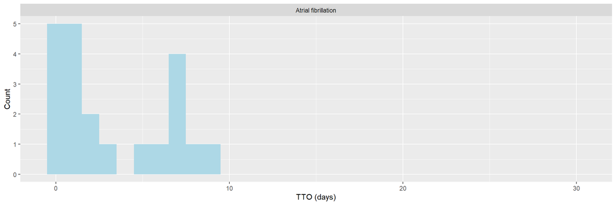

The TTO signal detection method tests if the distribution of Atrial fibrillation post RSV (AREXVY) is significantly different from the distribution of Atrial fibrillation post other vaccines using a two-sample Kolmogorov-Smirnov test [2]. The threshold for being flagged as a signal of unexpected time-to-onset distribution is a P-value <0.001 and a distance between the two empirical distributions larger than 20%. Under the assumption of no causality and no bias, it would have been expected that the time-to-onset distribution for “Atrial fibrillation” would have been the same post RSV (AREXVY) than post other vaccines.

It means that the quantified causality criterion of temporality is **not met**.

*It is to be noted that the nature of the spontaneous report does not provide reliable estimates of the temporal relationship between the exposure and the occurrence of the events as there is the reporting bias over time: the latter the event occurs after exposure, the less chance it has to be reported. Other biases could distort the reported time-to-onset distribution (media attention, etc.)*

## 1.3 Overall

Based on the screening of the Empirical Bayes Geometric Mean (EBGM) and the screening of the time-to-onset distribution,the vaccine-event combination “RSV (AREXVY) - Atrial fibrillation” is **considered as quantitative signal**.

# 2 Signal History

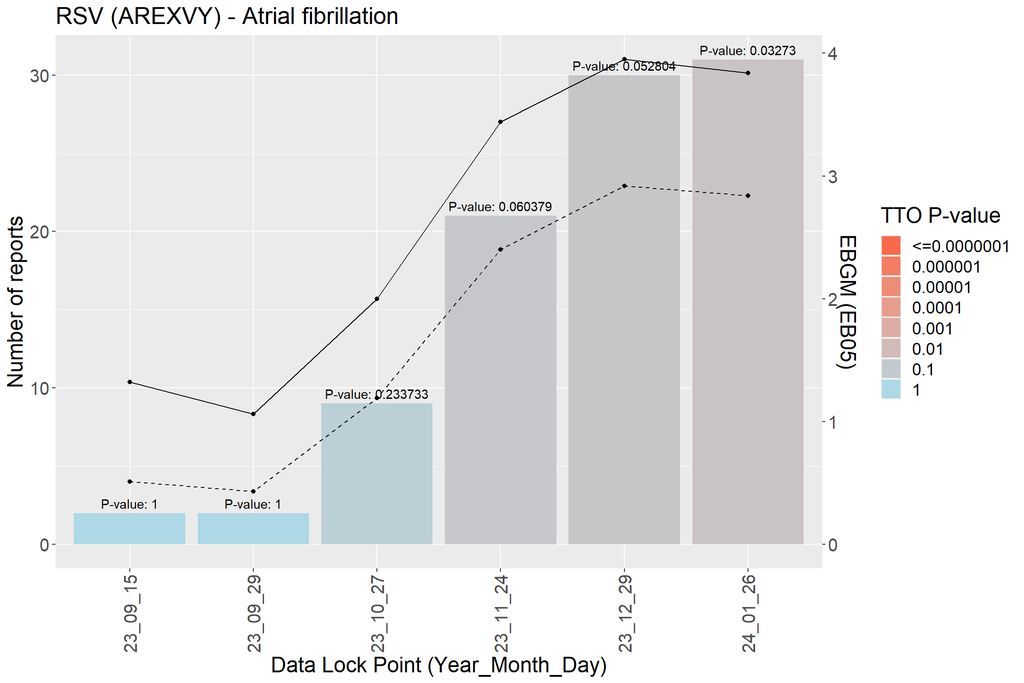

# 3 Case series

## 3.1 Seriousness

A total of 31 reports of Atrial fibrillation were received post exposure to RSV (AREXVY). Among them:

- 0 (0.0 %) were fatal cases.
- 1 (3.2 %) were life threatening cases.
- 5 (16.1 %) were hospitalized cases.
- 0 (0.0 %) were emergency room cases.
- 0 (0.0 %) were cases with disabilies.

## 3.2 Demographic characteristics

31 cases of Atrial fibrillation post RSV (AREXVY) were reported in VAERS:

- Among them, there were 13 (41.9%) female cases and 9 (29%) male cases while the overall female:male ratio is 68:25%.
- The mean (median) age for patients presenting symptoms of Atrial fibrillation was 73 (72) years while the overall mean (median) age was 70 (71) years.
- The top 5 contributing US states for patients presenting symptoms of Atrial fibrillation were NA ( 32.3 %) , FL ( 12.9 %) , IL ( 9.7 %) , CA ( 6.5 %) , MN ( 6.5 %) while overall the top 5 of contributing US states are NA ( 12.6 %) , FL ( 8.9 %) , CA ( 8.3 %) , NY ( 6.1 %) , TX ( 4.3 %)

# 4 Manufacturing

# 5 Listing of the cases

Narratives can be made visible clicking on the ⊕ symbol.

|  | VAERS ID | Sex/Age (Years) | Receipt Date | Seriousness status | List of symptoms | New | SYMPTOM_TEXT |
| --- | --- | --- | --- | --- | --- | --- | --- |
| &oplus; | 2729900 | M/87 | 01/04/2024 | Hospitalized | Acute kidney injury, Atrial fibrillation | Yes | Afib and AKI |
| &oplus; | 2739692 | F/68 | 01/24/2024 |  | Atrial fibrillation, Cardioversion, Discomfort, Electrocardiogram, Fatigue, Feeling jittery, Heart rate increased | Yes | Paroxysmal Rapid Afib with weakness discomfort jitters fatigue starting about 2 pm on January 18 2024 Took a nap ate a small dinner but could still feel that my pulse was not in sinus rhythm and that … |
| &oplus; | 2680502 | F/65 | 09/08/2023 |  | Atrial fibrillation, Heart rate irregular | No | IRREGULAR HEART BEATS AND A FIB |
| &oplus; | 2681103 | M/73 | 09/11/2023 | Hospitalized | Atrial fibrillation, Brain natriuretic peptide increased, Chest X-ray abnormal, Echocardiogram abnormal, Ejection fraction normal, Electrocardiogram abnormal, Feeling abnormal, Full blood count normal… | No | Atrial Fibrillation with rapid ventricular response new onset rate now controlled on Diltiazem however Afib persists Only symptoms felt loopy Wife is a physician and heard Afib upon auscultation Hospi… |
| &oplus; | 2689043 | F/76 | 09/30/2023 |  | Atrial fibrillation | No | PATIENT REPORTS THAT EMERGENCY DEPARTMENT DIAGNOSED HER WITH ATRIAL FIBRILLATION SHE WAS OBSERVED AT THE HOSPITAL AND DOES NOT RECALL THE MEDICATIONS SHE WAS GIVEN SHE REPORTS FEELING WELL TODAY |
| &oplus; | 2692699 | M/72 | 10/09/2023 |  | Atrial fibrillation | No | Basically I went into Afib it happened Friday a few hours after I got the vaccine Then it happened again at 515am this morning and I am still in afib right now I just checked and my heart rate is at 1… |
| &oplus; | 2693415 | F/70 | 10/10/2023 | Life threatening &amp; Hospitalized | Asthenia, Atrial fibrillation, Cardiac pacemaker insertion, Chills, Condition aggravated, Pyrexia | No | terrible chills fever |
| &oplus; | 2694666 | U/NA | 10/12/2023 |  | Atrial fibrillation | No | reoccurrence of A Fib This serious case was reported by a nurse via sales rep and described the occurrence of atrial fibrillation in a patient who received RSVPreF3 adjuvanted Arexvy for prophylaxis C… |
| &oplus; | 2697065 | F/77 | 10/17/2023 |  | Atrial fibrillation, Electrocardiogram abnormal | No | I received the shot September 5th On September 12th my Watch alerted me I had atrial fibrillation My watch continued to give me daily alerts I was on a vacation and went to my doctor when I got home o… |
| &oplus; | 2700781 | F/72 | 10/24/2023 |  | Atrial fibrillation | No | Patient was found to be in new onset Atrial Fibrilation |

[output cut: 21 more lines]

# 6 Disclaimer

This analysis is exploratory only and authors cannot be held responsible for any decision made using these data. It is important to distinguish quantitative signals such as disproportionate reporting, unexpected time-to-onset patterns or cluster from safety signals. Only a qualitative review using multiple data source (literature, clinical trials, etc.) and multiple causality criteria assessment could qualify quantitative signals into safety signals.

# 7 References

[1] Dumouchel W. Bayesian data mining in large frequency tables, with an application to the FDA spontaneous reporting system. Am Stat 1999; 53: 177–190.

[2] Van Holle L et al, Using time‐to‐onset for detecting safety signals in spontaneous reports of adverse events following immunization: a proof-of-concept study. Pharmacoepidemiology and Drug Safety 21 (6), 603-610.